# Advanced Seaborn (Optional)

In this mini-course of advanced Seaborn, we are going to focus on two learning objectives: first, we produce data visualizations with Seaborn, and second, we apply graphical techniques used in exploratory data analysis (EDA) using Seaborn. This is a semi-hands-on project that we will work together to solve real-life problems about Breast Cancer Wisconsin using visualization toolkits.

By the end of this course, you will be able to generate publication-quality graphs using Seaborn and Python to analyze data.

## Tumor Diagnosis Exploratory Data Analysis in Seaborn

The Breast Cancer Diagnostic dataset is retrieved from the UCI Machine Learning Repository, and could be downloaded there. The data describe the characteristics of digitized image for fine needle aspirate (FNA) of a breast mass. Here is a list of the attributes of the dataset.

**Attribute Information**:

Ten real-valued features are computed for each cell nucleus:

1. radius (mean of distances from center to points on the perimeter)
2. texture (standard deviation of gray-scale values)
3. perimeter
4. area
5. smoothness (local variation in radius lengths)
6. compactness (perimeter^2 / area - 1.0)
7. concavity (severity of concave portions of the contour)
8. concave points (number of concave portions of the contour)
9. symmetry
10. fractal dimension ("coastline approximation" - 1)

The mean, standard error and "worst" or largest (mean of the three largest values) of these features were computed for each image, resulting in 30 features. For instance, field 3 is Mean Radius, field 13 is Radius SE, field 23 is Worst Radius.

All feature values are recoded with four significant digits.

Missing attribute values: none

Class distribution: 357 benign, 212 malignant

```python
# We start by importing all necessary packages for exploratory data analysis. They are numpy
import numpy as np
# pandas for data processing
import pandas as pd
# seaborn and matplotlib to tackle main data visualization tasks.
import seaborn as sns
import matplotlib.pyplot as plt

# Now, let's import the Breast Tumor Dataset
data = pd.read_csv('assets/breast_tumor.csv')
# and take a glimse of the first few rows.
data.head()
```

|  | id | diagnosis | radius_mean | texture_mean | perimeter_mean | area_mean | smoothness_mean | compactness_mean | concavity_mean | concave points_mean | ... | texture_worst | perimeter_worst | area_worst | smoothness_worst | compactness_worst | concavity_worst | concave points_worst | symmetry_worst | fractal_dimension_worst | Unnamed: 32 |
| --- | --- | --- | --- | --- | --- | --- | --- | --- | --- | --- | --- | --- | --- | --- | --- | --- | --- | --- | --- | --- | --- |
| 0 | 842302 | M | 17.99 | 10.38 | 122.80 | 1001.0 | 0.11840 | 0.27760 | 0.3001 | 0.14710 | ... | 17.33 | 184.60 | 2019.0 | 0.1622 | 0.6656 | 0.7119 | 0.2654 | 0.4601 | 0.11890 | NaN |
| 1 | 842517 | M | 20.57 | 17.77 | 132.90 | 1326.0 | 0.08474 | 0.07864 | 0.0869 | 0.07017 | ... | 23.41 | 158.80 | 1956.0 | 0.1238 | 0.1866 | 0.2416 | 0.1860 | 0.2750 | 0.08902 | NaN |
| 2 | 84300903 | M | 19.69 | 21.25 | 130.00 | 1203.0 | 0.10960 | 0.15990 | 0.1974 | 0.12790 | ... | 25.53 | 152.50 | 1709.0 | 0.1444 | 0.4245 | 0.4504 | 0.2430 | 0.3613 | 0.08758 | NaN |
| 3 | 84348301 | M | 11.42 | 20.38 | 77.58 | 386.1 | 0.14250 | 0.28390 | 0.2414 | 0.10520 | ... | 26.50 | 98.87 | 567.7 | 0.2098 | 0.8663 | 0.6869 | 0.2575 | 0.6638 | 0.17300 | NaN |
| 4 | 84358402 | M | 20.29 | 14.34 | 135.10 | 1297.0 | 0.10030 | 0.13280 | 0.1980 | 0.10430 | ... | 16.67 | 152.20 | 1575.0 | 0.1374 | 0.2050 | 0.4000 | 0.1625 | 0.2364 | 0.07678 | NaN |

5 rows × 33 columns

```python
# Separate tumor targets from tumor data
target = data['diagnosis']
drop_cols = ['Unnamed: 32', 'id', 'diagnosis']
indep_variable = data.drop(drop_cols, axis = 1)
indep_variable.head()
```

|  | radius_mean | texture_mean | perimeter_mean | area_mean | smoothness_mean | compactness_mean | concavity_mean | concave points_mean | symmetry_mean | fractal_dimension_mean | ... | radius_worst | texture_worst | perimeter_worst | area_worst | smoothness_worst | compactness_worst | concavity_worst | concave points_worst | symmetry_worst | fractal_dimension_worst |
| --- | --- | --- | --- | --- | --- | --- | --- | --- | --- | --- | --- | --- | --- | --- | --- | --- | --- | --- | --- | --- | --- |
| 0 | 17.99 | 10.38 | 122.80 | 1001.0 | 0.11840 | 0.27760 | 0.3001 | 0.14710 | 0.2419 | 0.07871 | ... | 25.38 | 17.33 | 184.60 | 2019.0 | 0.1622 | 0.6656 | 0.7119 | 0.2654 | 0.4601 | 0.11890 |
| 1 | 20.57 | 17.77 | 132.90 | 1326.0 | 0.08474 | 0.07864 | 0.0869 | 0.07017 | 0.1812 | 0.05667 | ... | 24.99 | 23.41 | 158.80 | 1956.0 | 0.1238 | 0.1866 | 0.2416 | 0.1860 | 0.2750 | 0.08902 |
| 2 | 19.69 | 21.25 | 130.00 | 1203.0 | 0.10960 | 0.15990 | 0.1974 | 0.12790 | 0.2069 | 0.05999 | ... | 23.57 | 25.53 | 152.50 | 1709.0 | 0.1444 | 0.4245 | 0.4504 | 0.2430 | 0.3613 | 0.08758 |
| 3 | 11.42 | 20.38 | 77.58 | 386.1 | 0.14250 | 0.28390 | 0.2414 | 0.10520 | 0.2597 | 0.09744 | ... | 14.91 | 26.50 | 98.87 | 567.7 | 0.2098 | 0.8663 | 0.6869 | 0.2575 | 0.6638 | 0.17300 |
| 4 | 20.29 | 14.34 | 135.10 | 1297.0 | 0.10030 | 0.13280 | 0.1980 | 0.10430 | 0.1809 | 0.05883 | ... | 22.54 | 16.67 | 152.20 | 1575.0 | 0.1374 | 0.2050 | 0.4000 | 0.1625 | 0.2364 | 0.07678 |

5 rows × 30 columns

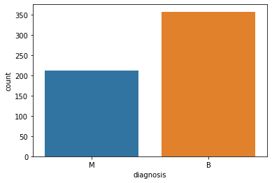

```python
# Plot Diagnosis Distributions
# The target contains the diagnosis with binary class labels, M or B, for malignant and benign tumors respectively.
# The sns.countplot function shows the counts of observations in each categorical bin using bars

ax = sns.countplot(target, label = "Count")
B, M = target.value_counts()

# Looks like a class imbalanced problem
```

```
(array([0, 1, 2, 3, 4, 5, 6, 7, 8, 9]),
 [Text(0, 0, 'radius_mean'),
```

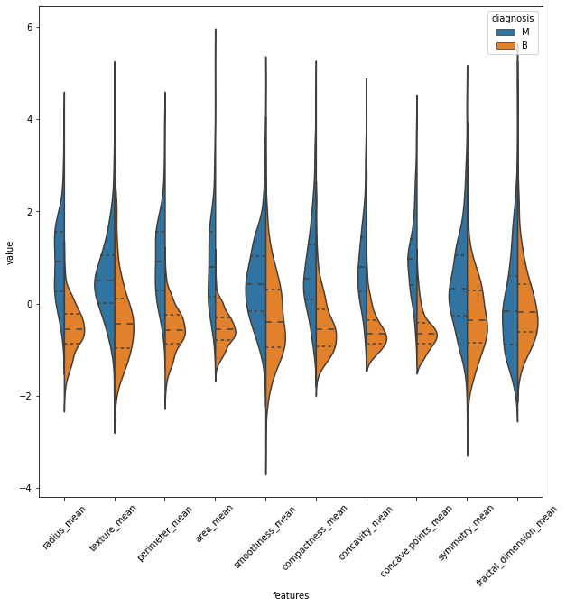

```python
# Visualizing Standardized Data with Seaborn

data = indep_variable
# As the columns in the data set take on values of varying range, we need to standardize
# the data before proceeding with further analysis and visualization.
data_std = (data - data.mean()) / data.std()

# To minimize clutter in our visualizations, we divide the features into three batches of ten
# features and produce separate plots for them.
data = pd.concat([target, data_std.iloc[:, 0:10]], axis = 1)
# Unpivot the data into wide format
data = pd.melt(data, id_vars = 'diagnosis',
              var_name = 'features',
              value_name = 'value')
plt.figure(figsize=(10, 10))
# The sns.violinplot function can show the standardized data and identify the difference between benign and
# malicious tumors. Inside the function, we use the hue parameter to determine that the diagnosis column in the
# data frame should be used for colour encoding.
sns.violinplot(x = 'features', y='value', hue='diagnosis',
               data = data, split = True, inner='quart')
plt.xticks(rotation=45)

# Violin plots are similar to box plots, except that they also show the probability density of the data
# at different values
# Check that the median or variability of the malign and benign are of huge difference.
# well-separated, beneficial for classification.
```

```
(array([0, 1, 2, 3, 4, 5, 6, 7, 8, 9]),
 [Text(0, 0, 'radius_se'),
```

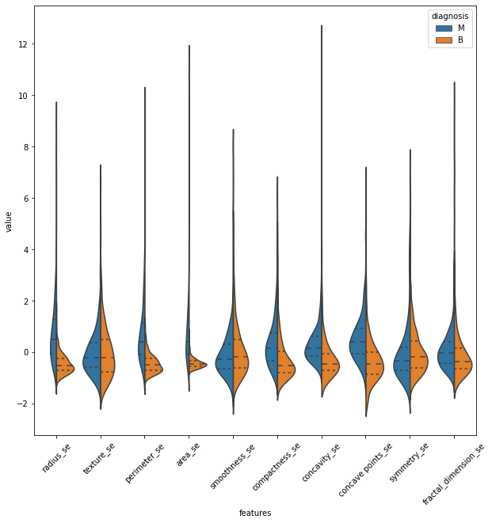

```python
# Violin Plots and Box Plots

# 11-20 features
data = pd.concat([target, data_std.iloc[:, 10:20]], axis = 1)
# Unpivot the data into wide format
data = pd.melt(data, id_vars = 'diagnosis',
              var_name = 'features',
              value_name = 'value')
plt.figure(figsize=(10, 10))
# hue indicates the color
sns.violinplot(x = 'features', y='value', hue='diagnosis',
               data = data, split = True, inner='quart')
plt.xticks(rotation=45)
```

```
(array([0, 1, 2, 3, 4, 5, 6, 7, 8, 9]),
 [Text(0, 0, 'radius_se'),
```

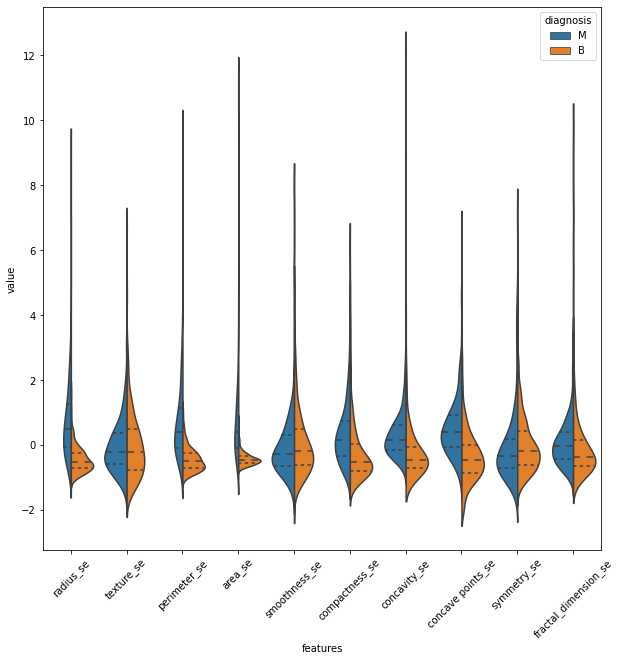

```python
# Boxplots
# 11-20 features
data = pd.concat([target, data_std.iloc[:, 10:20]], axis = 1)
# Unpivot the data into wide format
data = pd.melt(data, id_vars = 'diagnosis',
              var_name = 'features',
              value_name = 'value')
plt.figure(figsize=(10, 10))
sns.violinplot(x = 'features', y='value', hue='diagnosis',
               data = data, split = True, inner='quart')
plt.xticks(rotation=45)
```

```
(array([0, 1, 2, 3, 4, 5, 6, 7, 8, 9]),
 [Text(0, 0, 'radius_se'),
```

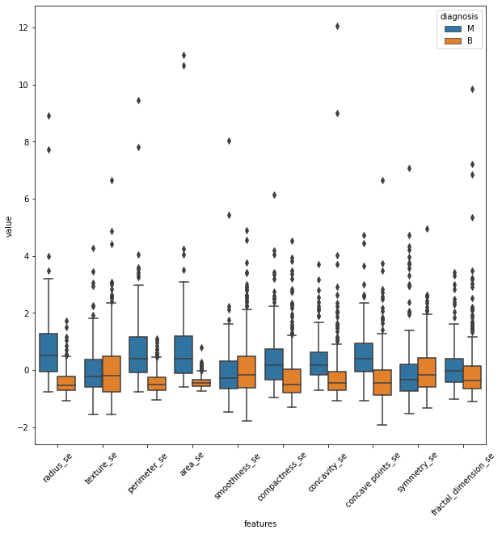

```python
# Box plots are especially useful in identifying outliers in the data.

plt.figure(figsize=(10, 10))
# hue indicates the color
sns.boxplot(x = 'features', y='value', hue='diagnosis',
            data = data)
plt.xticks(rotation=45)
```

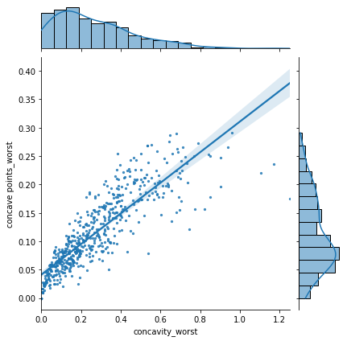

```python
# Using Joint Plots for Feature Comparison
# Joint plots come in handy to illustrate the relationship between two features.

sns.jointplot(indep_variable.loc[:, 'concavity_worst'],
             indep_variable.loc[:, 'concave points_worst'],
             kind = 'reg', scatter_kws={"s": 5})
# draw a scatter plot with marginal histograms and kernel density fits.
# relationship between any two features using the Pearson correlation coefficient of the regression
# through our scatter plot.
```

```
(array([0, 1, 2, 3, 4, 5, 6, 7, 8, 9]),
 [Text(0, 0, 'radius_mean'),
```

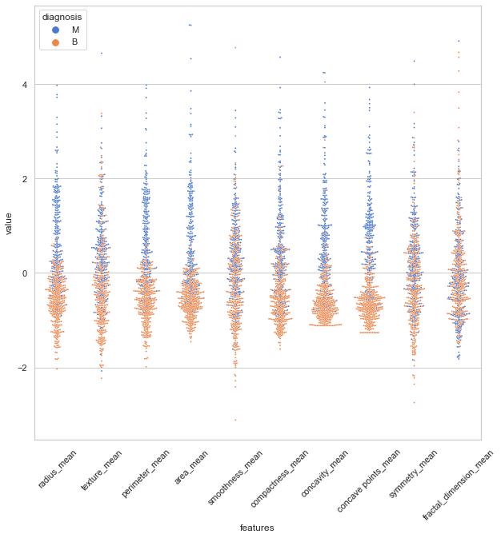

```python
# Observing the Distribution of Values and their Variance with Swarm Plots

# # We have learned that violin plots are a great tool for visualizing sparse distributions. As our data set contains close to 600 rows,
# we might want to simply display each point in the same visualization.

# Aesthetically pleasing
sns.set(style = 'whitegrid', palette='muted')

# Reuse the standardized data
data = pd.concat([target, data_std.iloc[:, 0:10]], axis = 1)
# Unpivot the data into wide format
data = pd.melt(data, id_vars = 'diagnosis',
              var_name = 'features',
              value_name = 'value')
plt.figure(figsize=(10, 10))

sns.swarmplot(x = 'features', y='value', hue='diagnosis',
               data = data, s = 1.8)
plt.xticks(rotation=45)
# Clear indication of classification
# some representation of the underlying distribution.
```

```
(array([0, 1, 2, 3, 4, 5, 6, 7, 8, 9]),
 [Text(0, 0, 'radius_se'),
```

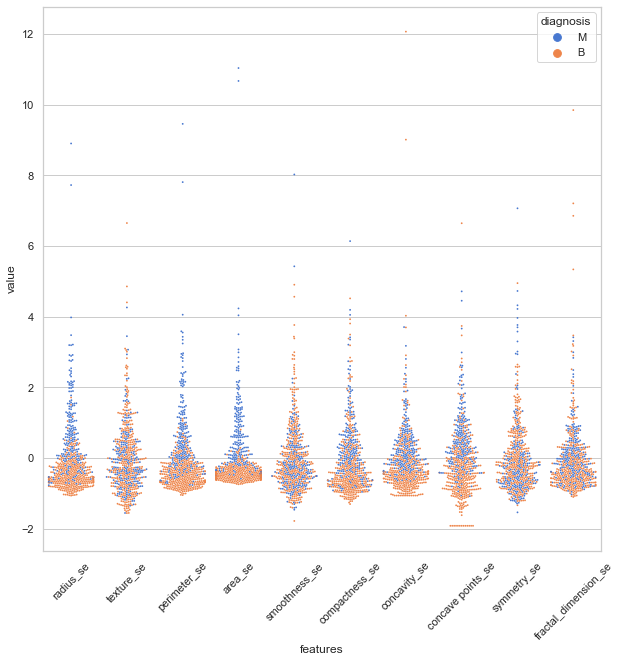

```python
data = pd.concat([target, data_std.iloc[:, 10:20]], axis = 1)
# Unpivot the data into wide format
data = pd.melt(data, id_vars = 'diagnosis',
              var_name = 'features',
              value_name = 'value')
plt.figure(figsize=(10, 10))
# hue indicates the color
sns.swarmplot(x = 'features', y='value', hue='diagnosis',
               data = data, s = 1.8)
plt.xticks(rotation=45)
```

```
(array([0, 1, 2, 3, 4, 5, 6, 7, 8, 9]),
 [Text(0, 0, 'radius_mean'),
```

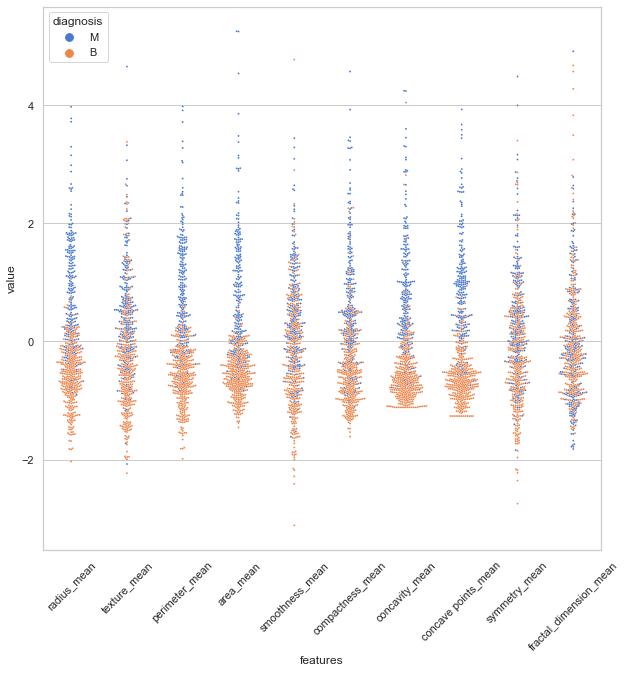

```python
data = pd.concat([target, data_std.iloc[:, 0:10]], axis = 1)
# Unpivot the data into wide format
data = pd.melt(data, id_vars = 'diagnosis',
              var_name = 'features',
              value_name = 'value')
plt.figure(figsize=(10, 10))
# hue indicates the color
sns.swarmplot(x = 'features', y='value', hue='diagnosis',
               data = data, s = 1.8)
plt.xticks(rotation=45)
```

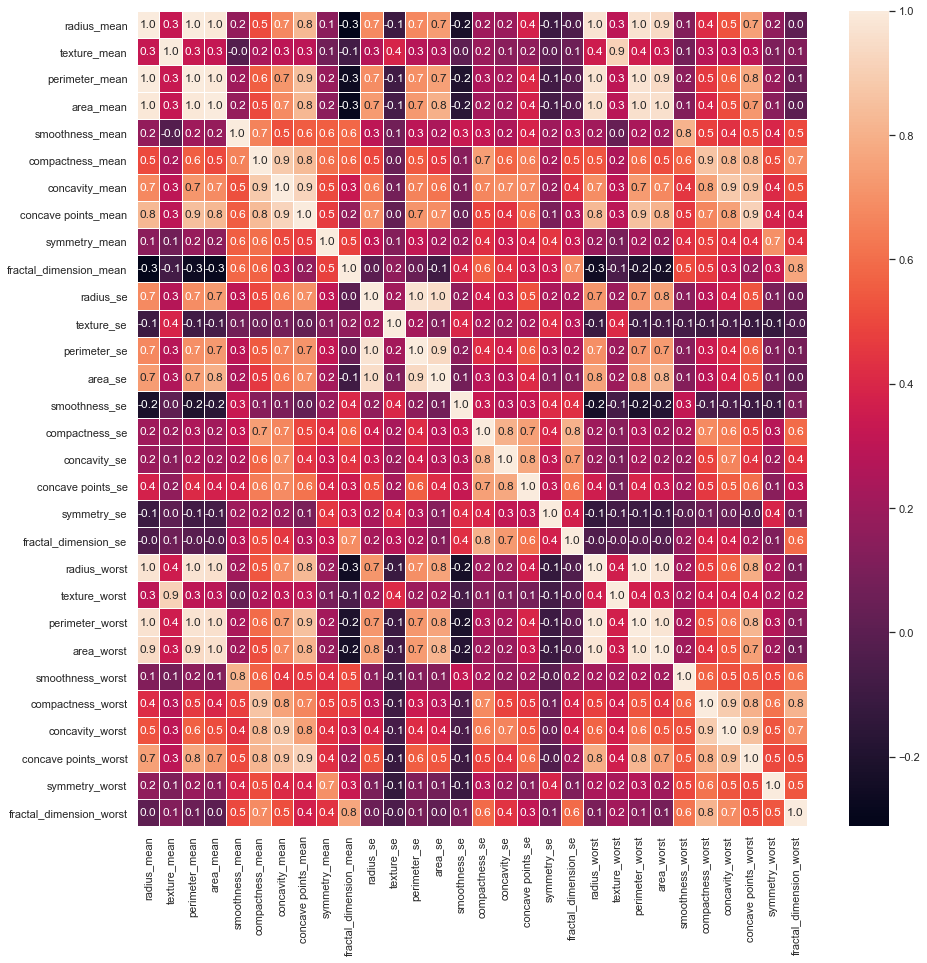

```python
# Observing all Pair-wise Correlations
# A good way to identify correlations between features is to visualize the correlation matrix as a heatmap.
# We use the sns.heatmap function to visualize all pair-wise correlations as a color-encoded grid
# Such a grid is typically named heatmap since the color scale can distinguish strong and weak correlations.
f, ax = plt.subplots(figsize=(15, 15))
sns.heatmap(indep_variable.corr(), annot = True,
           linewidth = .6, fmt='.1f', ax = ax)
# Diagonal cells are 1. Pairwise correlation for the rest.
# Should we combine several features? Shall we drop one of the two correlated features?
```

[figure not shown]

Created in Deepnote